# Russian Security State / Lecture 14: Military Analysis 101

GOVT-5519 / IPOL-3519 / REES-5519 / SEST-6763

Yuri M. Zhukov

Associate Professor

School of Foreign Service

Department of Government

Georgetown University

October 21, 2025

**Today’s objectives**

1. *Introduce*: basic terms of reference for military analysis
2. *Discuss*: merits of different measures of effectiveness
3. *Consider*: how requirements for a “short, lightning war” differ from those of a “long war of attrition”

# The Ends

## Levels of Analysis

**Three levels of war**  
(Soviet/Russian counterparts in grey)

1. Strategic (operational-strategic)
   1. how to win war
   2. *objectives*: destroy enemy armed forces, will to fight
   3. *units* (ob’edineniya): theaters, army groups, fronts
2. Operational (operational-tactical)
   1. how to win campaign
   2. *objectives*: reach/gain territory
   3. *units* (ob’edineniya/soedineniya): armies, corps
3. Tactical (tactical)
   1. how to win battle
   2. *objectives*: take hill, trench
   3. *units* (soedineniya/podrazdeleniya): division, brigade, battalion

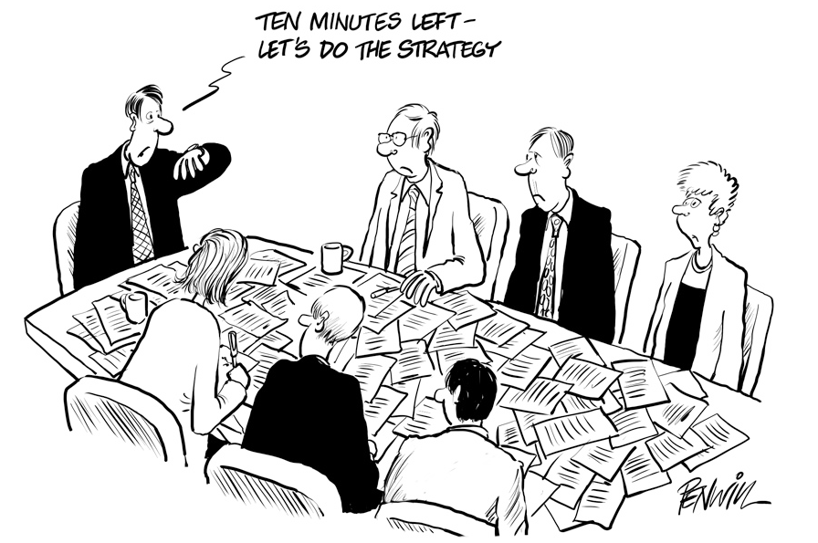

Wrong approach

**Comparative military units** (ground warfare): US/NATO, USSR/RF

| **Symbol** | **Name** | **Troops** | **Commander** |
| --- | --- | --- | --- |
| $\bullet$ | Squad | 8-15 | Sergeant |
|  | Otdelenie | 6-12 | *Serzhant* |
| $\bullet\bullet\bullet$ | Platoon | 20-60 | 2nd/1st Lieutenant |
|  | Vzvod | 18-48 | *Praporshchik/(Mladshiy) Leytenant* |
| I | Company | 100-250 | Captain/Major |
|  | Rota | 40-110 | *Kapitan/Mayor* |
| II | Battalion | 500-600 | Lt Colonel |
|  | Batal’on | 400-700 | *Podpolkovnik* |
| III | Regiment | 1,000-3,000 | Colonel |
|  | Polk | 500-2,500 | *Polkovnik* |
| X | Brigade | 3,000-5,000 | Colonel/Brigadier |
|  | Brigada | 1,000-3,000 | *Polkovnik* |
| XX | Division | 10,000-20,000 | Maj General |
|  | Diviziya | 6,000-12,000 | *General-Mayor* |
| XXX | Corps | 40,000-100,000 | Lt General |
|  | Korpus | 15,000-50,000 | *General-Leytenant* |
| XXXX | Army | 200,000-500,000 | General |
|  | Armiya | 100,000-120,000 | *General-Polkovnik/General Armii* |
| XXXXX | Army Group | 500,000-1,000,000 | Field Marshal |
|  | Front | 900,000-1,300,000 | *General Armii/Marshal* |

**Winning battles, losing wars**

1. Aggregation problem
   1. tactical victory $\neq$ strategic victory
   2. tactical brilliance can be in service of deeply flawed strategies
   3. tactical superiority can prolong war past point where strategic success is possible
2. Loss of strategic initiative
   1. losing side gradually loses ability to make strategic decisions, then operational decisions

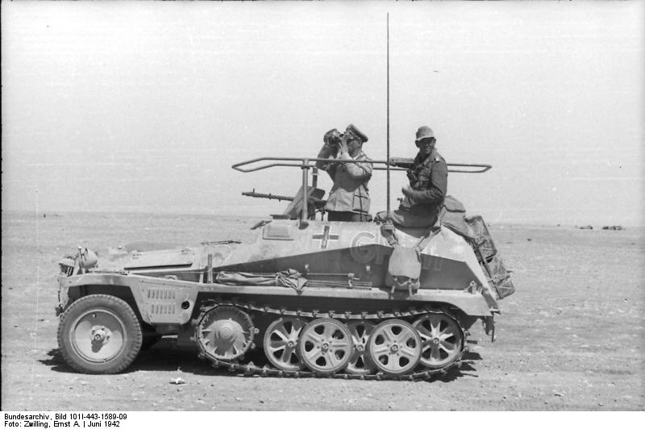

Desert outfoxed

## Measures of Effectiveness

**How can we tell if we’re winning?**

1. Loss-based metrics
   1. losses inflicted (“body counts”)
   2. ratio of enemy/friendly losses (loss-exchange ratio, LER)
   3. ratio of civilian-to-military losses
2. Geographic metrics
   1. area of territory gained or lost
3. Temporal metrics
   1. duration of operation/battle
4. Political metrics
   1. political concessions from enemy
   2. popular support
   3. political “end state” reached

*Discussion*

- Are some MOE’s better than others?
- Which are appropriate for strategic vs. operational or tactical levels?

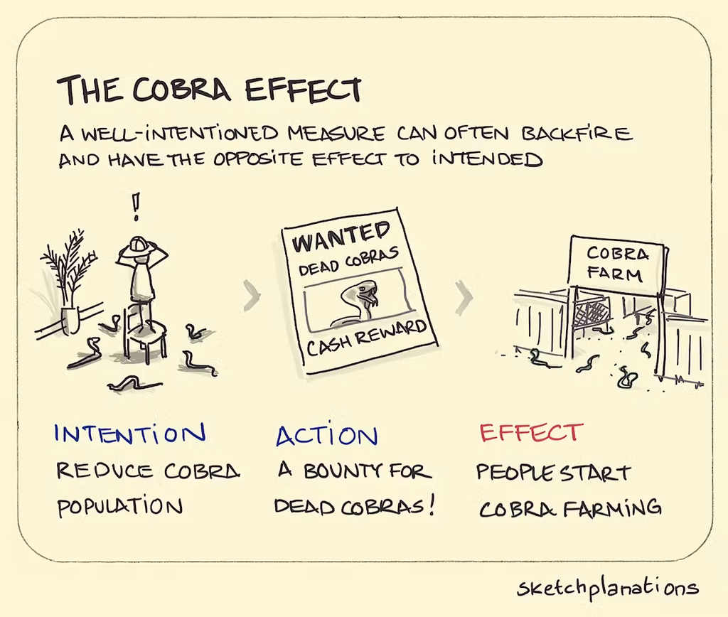

Avoid this

# The Means

## Predictors of Victory and Defeat in Battle

| **Balance of power** | **Force employment** | **Geography** | **Information** | **Chance** |
| --- | --- | --- | --- | --- |
| numbers | doctrine | distance | surprise | weather |
| replacement of losses | strategy | terrain | intelligence | timing |
| industry/production | training | climate | analysis | luck |
| logistics | officer quality | roads | communication |  |
| natural resources | technology | fortifications |  |  |

**Balance of power**

1. Numbers
   1. which side has numerical superiority?
2. Replacement of losses
   1. which side can more easily recover from attrition?
3. Industrial capacity
   1. which side can produce at scale?
4. Natural resources
   1. which side has access to more raw materials?
5. Logistics
   1. which side can deploy troops and deliver supplies cheaper & faster?

[figure not shown]

Outproduce to win

**Force employment**

1. Doctrine
   1. which side is more prepared for expected type of combat?
2. Strategy
   1. which side has smarter/clearer vision for how to win war?
3. Training
   1. are troops ready and able to implement the chosen strategy?
4. Officer & NCO quality
   1. are small team leaders capable of independent decisions?
   2. how well is discipline maintained?
   3. are senior leaders capable of managing large-scale maneuvers?
5. Technology
   1. which side has more modern and/or efficient equipment?

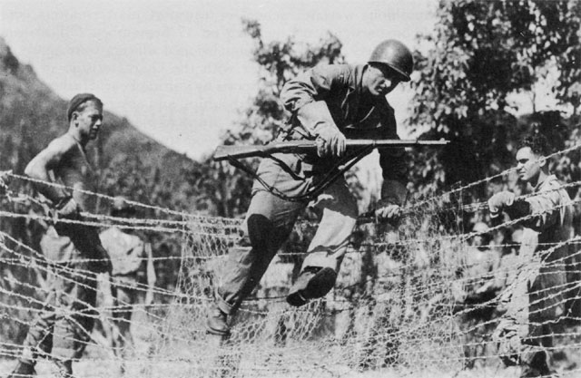

Outtrain to win

**Geography**

1. Distance
   1. how distant is the theater?
   2. how wide is the front?
2. Terrain
   1. how severe are natural obstacles to mobility/visibility? (mountains, forests, swamps, river crossings)
3. Climate
   1. how will heat/cold/humidity affect troops, equipment?
4. Roads
   1. how many avenues of approach, ground lines of communication (GLOCs) are available?
   2. what is the capacity of the roads?
   3. how secure are the roads?
5. Fortifications
   1. how robust are man-made obstacles vs. advancing troops?

[figure not shown]

Bezdorizhzhya

**Information**

1. Surprise
   1. which side can better elude other’s expectations?
2. Intelligence collection
   1. which side has more information on enemy capabilities, actions?
3. Intelligence analysis
   1. which side can better separate signal from noise?
4. Communications
   1. which side can more effectively coordinate across/within units (horizontal)?
   2. which side has more efficiently communicate orders, feedback up/down the chain (vertical)?

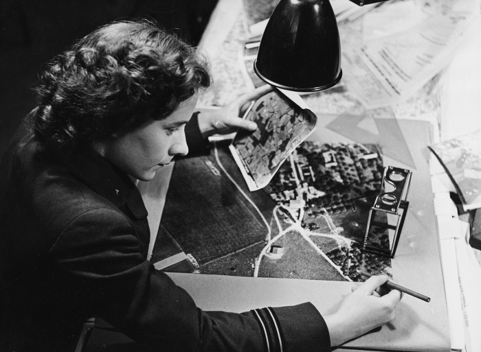

Signal & noise

**Fortune**

1. Weather
   1. how might inclement weather affect mobility, visibility, operational tempo?
2. Timing
   1. which side managed to show up at right place and right time?
3. Luck
   1. which way is the wind blowing?
   2. who woke up with a migraine?
   3. whose rifle jammed?
   4. why did birds strike jet engine?

[figure not shown]

Lucky you

## Requirements for Short vs. Long Wars

**Case study: Blitzkrieg** (lightning war)

1. Political-economic strategy
   1. short, decisive military campaigns vs. weak, isolated opponents
   2. war “on cheap”, without total mobilization of society, economy
2. Operational concept  
   (attack, breakthrough, envelop)
   1. tanks smash weak point in defenses, encircle enemy troops
   2. motorized infantry consolidate gains, free tanks for next advance
   3. regular infantry arrives, frees motorized units for next advance
   4. tactical air power
      - destroy enemy air force
      - disrupt communications
      - close air support

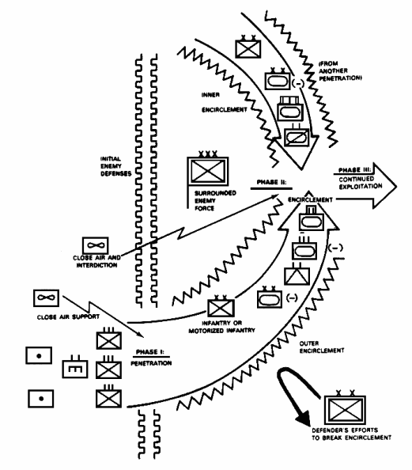

Speed kills

*Which resource/capability is advantageous for which contingency?*

1. Large population
2. Natural resources
3. Industrial capacity
4. Strategic lift capabilities
5. Rapid decision cycles
6. Combined arms warfare
7. Decentralized command & control
8. Junior officer training
9. Small unit initiative
10. Visionary generals
11. Democracy
12. Economic self-sufficiency

The choices are:

Short War

Long War

Neither/Both

**NEXT MEETING**

*USSR at War: Stalin’s Bid for Strategic Depth* (Th, Oct. 23)

- why did USSR enter into non-aggression pact with Germany?
- what explains initial Soviet battlefield failures vs Finland?
- what explains the eventual outcome of the Soviet-Finnish War?